# 7. Marginal structural model

2023-06-27

> [*Back to content page*](https://flatter11.github.io/6040/)

Learning objective

- Recognize the situation in longitudinal study with time-dependent confounder
- Analyse longitudinal data using Marginal Structural Models (MSM), accounting for endogenous confounding
- Recognize the assumptions of MSM
- Interpret the results from MSM

# 1 Endogenous confounding

## Endogenous confounding

Endogenous confounding = time-dependent confounders

- Difficult to establish causality in observational study
- Figure: If there is time element, confounder L is also mediators, e.g. A1 -> L2 -> Y. But we cannot adjust for mediator. Example:
  - Obesity (A), CVD (L), all-cause mortality (Y)  
    Obesity => CVD  
    CVD unlikely to do exercise => Obesity
  - Influenza vaccine (A), health status (L), influenza virus infection (Y)
  - Depressive symptoms (A), health behavior (L), stroke (Y)

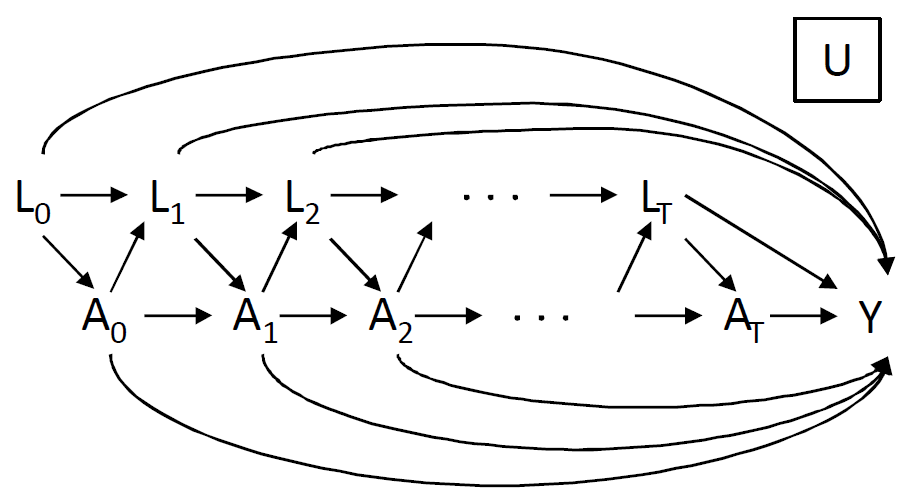

## MSM using IPW

Strategy to control for endogenous confounding – MSM

- Imagine we can ‘clone’ the subject with identical characteristics, except taking opposite treatment (counterfactuals) => can estimate causal effect by Y1 - Y0
  - We can regard **counterfactuals as missing data** (unobservable in reality, each subject either take or not take drug)
  - Then use **IPW to reweight the dataset to balance the predictor/confounder on two groups** (like in RCT)
    - At each time point, the probability was estimated conditional on past confounders and may also on past responses (depending on the assumed causal structure)
    - Treatment can also be time-dependent
    - Can also handle dropouts similarly
    - Called propensity score for time-independent case
- **Marginal Structural Model (MSM)** = the model that use IPW mentioned above
  - “Marginal” = do not model the correlation between observed outcome and counterfactuals (we don’t care abt it)
  - “Structural” = model the probabilities of counterfactuals varaibls (terminology from econometrics or social science)
  - Use Inverse probability of treatment weighed (IPTW) estimator
    - => Can then be applied to GLM, Cox regression or GEE  
      MSM just a way to handle time-dependent confounding, we still need to specify relationship between outcome Y and covariant X like linear or logistic regression

Assumptions of MSM

1. No unmeasured confounders
   - However not testable
   - Need to search literature to possible common confounders, or do sensitivity analysis
2. Experimental treatment assignment / Structural positivity
   - Cannot have *complete confounding (probability = 0 or 1)*
     - complete confounding = confounding variable perfectly predict exposure (they perfectly correlates, correlation between them is 1 or -1) so we cannot separate effect from confounding and exposure.
     - weighting should be away from 0 or 1
3. Models are specified correctly, e.g. linear or logistic regression

## Steps for MSM

Recap on IPW

- Have some weight (probability of treatment) to balance the conditioning
  - **Unstable weight** is problematic – Extremely large weighting may dominate the further weighted analysis and increase the variability
  - Hence **stablilized weight** is proposed – P(A) appearing in both numerator and denominator helps to reduce the variation of the weights  
    Unlikely to get extreme value , e.g. when unstable weight is 200, stable weight is 100
    - Always use stablized weight for continuous exposure variable
    - Stabilized weight for diff time point: can multiply weight tgt if > 1 time point

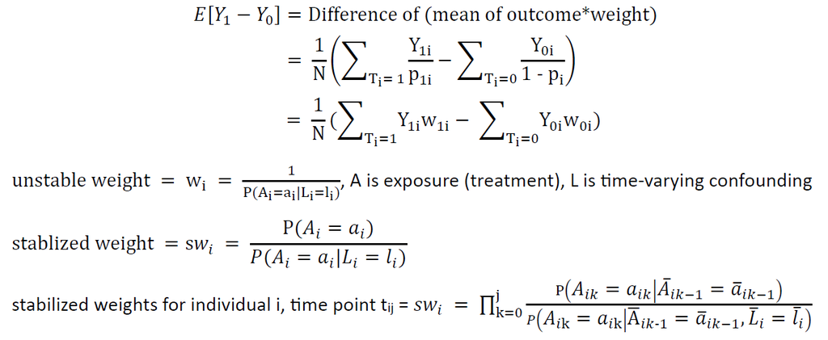

Standard error for MSM

- **Robust standard error estimator** is needed to account for correlation (e.g. sandwich estimator) because
  - correlation is induced by weighting
  - longitudinal data also hv within-subject correlations
- Bootstrap method to obtain the standard error can also be used.

# 2 MSM without time(R)

## R code

- R package: ipw.
- `ipwpoint, ipwtm` to generate inverse probability weighting for situations with time-independent and time-varying exposure/confounder
  - `ipwpoint(exposure, family, link, numerator = NULL, denominator, data, )`
    - **exposure**…the exposure/treatment variable of interest
    - **family**…the famiily of the relation, e.g. “binomial”, “multinomial”, “ordinal”, “gaussian”
    - **link**…the link function, e.g. “logit” for logistic regression, “gaussian” for linear regression, other links are also possible
    - **numerator**…the predictors in the numerator of IPW. If unspecified, unstabilized weights = 1 will be used
    - **denominator** … the predictors in the denominator of IPW. Confounders should be included.

## 1 Example – generate dataset

First, generate simulated data from van der Wal et.al 2011 (A)

1. $L \sim N(10, 5^2)$
2. $logit(P(A=1)) = -10 + L$
3. $Y = 10A + 0.5L - 10 + \epsilon, \text{where }\epsilon \sim N(0, 5^2)$

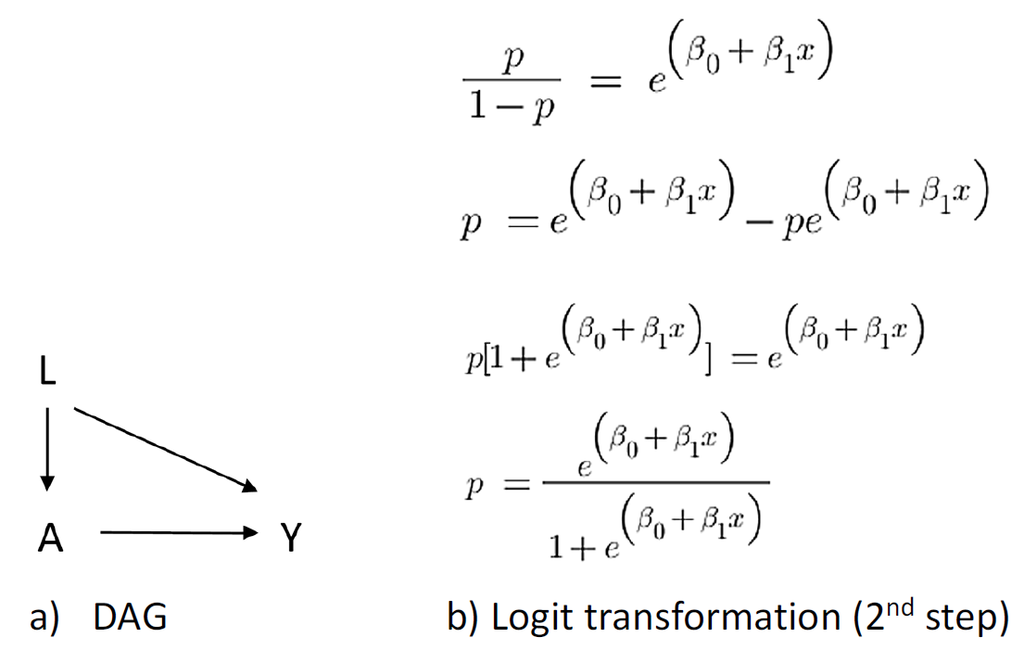

So we know that the true causal effect of A on Y is 10 (Y = 10A + …)

- This can be estimated by standard linear regression by adjusting for L
- An alternative is to use IPTW estimator => learn this in this lecture
1. Estimate the weights (B)
2. Obtaining IPTW estimates with package `survey` (C)
   - use `svyglm()` to fit the MSM model applying IPW
     - `svydesign(id, weights, data)` to specify the weighting (id ~ 1 for no clusters)
     - svyglm will give the robust estimator for the standard error, accounting for the clustering effect introduced by weighting
   - The IPW will balance the confounder (L) and hence is not adjusted for in the model (l already handled by weighting, so y~a instead of y~a+l)

```r
### A Generate dataset
set.seed(111)
## 1 Simulate 1000 observations (L) following normal distribution
n <- 1000
simdat <- data.frame(l = rnorm(n, 10, 5))
## 2 Generate A based on L
a.link <- simdat$l - 10
pa <- exp(a.link)/(1 + exp(a.link)) #Probability of having treatment in each individual
simdat$a <- rbinom(n, 1, prob = pa) #Generate 1000 treatment status based on probability obtained
## 3 Generate Y based on A and L
simdat$y <- 10*simdat$a + 0.5*simdat$l - 10 + rnorm(n, 0, 5)
simdat[1:4,] #Preview of simulated dataset
```

```
##           l a           y
## 1 11.176104 1  12.9941002
## 2  8.346321 0  -0.5416105
## 3  8.441881 0 -11.8720489
## 4 -1.511728 0  -9.6681398
```